# ADHDtraits

Catherine Sheen

25/05/2021

## Introduction

### Background

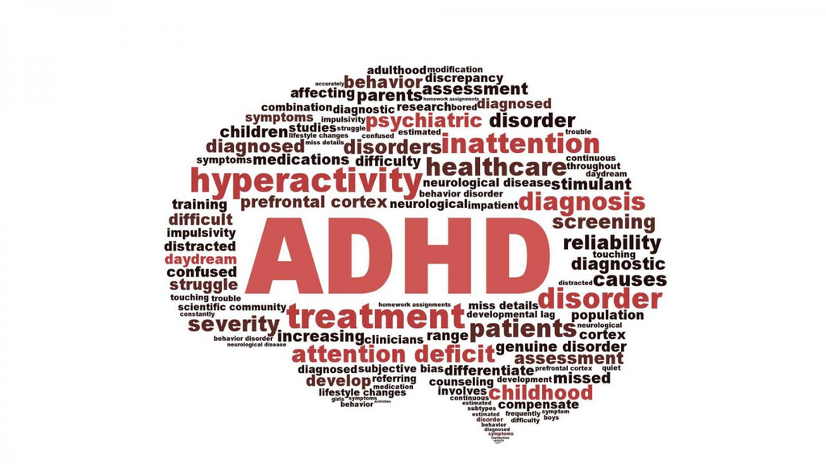

### Research Question

The visualisation with explore the following question:

**Does the relationship between ADHD traits and depression symptoms exist through difficulties in emotion regulation?**

### Data Origin

The data used in this project was collected as part of a BSc (hons) Forensic Psychology level 6 project at Staffordshire University titled *“Is there a relationship between emotion regulation, empathy and depression in healthy individuals reporting ADHD traits?”* by Catherine Sheen*. It builds on the previous findings that statistically emotion regulation mediated the relationship between depression symptoms and ADHD traits and endevours to visually represent these findings. The analysis includes results from the [Adult ADHD self-report Scale (ASRS)](https://doi.org/10.1080/10401230600801077), the [Difficulties in Emotion Regulation Scale (DERS)](https://doi.org/10.1023/B:JOBA.0000007455.08539.94), and the [Center for Epidemiological Studies Depression Scale (CES-D)](https://doi.org/10.1177%2F014662167700100306).

*Many thanks to Dr Justine Drakeford for being a fantastic project supervisor and mentor during my undergraduate studies.

## Data wrangling

Before any visualisations could be conducted on the data, a large amount of data warngling was required to get it to a useable form.

```r
#open library packages

library(here)
library(tidyverse)
library(forcats)
library(fBasics)
library(reshape2)
library(shiny)
library(plotly)

#load dataset
data <- read.csv(here("raw", "Raw.csv"))

#show current column names
colnames(data)

#remove the consent form columns Q2_1:Q2_8, quit question and empathy quotient
df = select(data,
            -c(Q2_1:Q2_8, Q6, Q8, Q10, Q12, Q14, Q16, Q18, Q11_1:Q11_60)
                          )
colnames(df)


#code column names
df <- df %>% rename("sex" = Q3,
                    "age" = Q4,
                    "ders" = Q5_1:Q5_36,
                    "cesd" = Q9_1:Q9_20,
                    "asrs" = Q17_1:Q17_18)

df <- df %>%  rename("fullattention" = Q19,
                                           "submit" = Q22)

#remove obsolete row 1
df <- df[-c(1), ]

# Add a ID column
df$id <- 1:nrow(df)

#making id column first
df <- df %>%  select(id, everything())


#recoding varaibles
df[,2] <- ifelse(df[,2] == "Male", 1, ifelse(df[,2] == "Female", 2, 3))

#ders
df[,4:39] <- ifelse(df[,4:39] == "Almost Never", 1,
                    ifelse(df[,4:39] == "Sometimes", 2,
                           ifelse(df[,4:39] == "Half the time", 3,
                                  ifelse(df[,4:39] == "Most of the time", 4,
                                         ifelse(df[,4:39] == "Almost Always", 5, 99)))))

#ces-d
df[,40:59] <- ifelse(df[,40:59] == "Rarely (less then a day)", 1,
                    ifelse(df[,40:59] == "Sometimes (1-2 days)", 2,
                           ifelse(df[,40:59] == "Occasionally (3-4 days)", 3,
                                  ifelse(df[,40:59] == "Most of the time (5-7 days)", 4, 99))))

#ASRS
df[,60:77] <- ifelse(df[,60:77] == "Never", 1,
                    ifelse(df[,60:77] == "Rarely", 2,
                           ifelse(df[,60:77] == "Something", 3,
                                  ifelse(df[,60:77] == "Often", 4,
                                         ifelse(df[,60:77] == "Very Often", 5, 99)))))


#reverse code values for CES-D
df[,c("cesd4", "cesd8", "cesd12", "cesd16")] <- 5-df[,
                                                     c("cesd4", "cesd8", "cesd12", "cesd16")]

#reverse code values for DERS
df[,c("ders1", "ders2", "ders6", "ders7", "ders8", "ders10", "ders17", "ders20", "ders22", "ders24", "ders34")] <- 6-df[,
                                c("ders1", "ders2", "ders6", "ders7", "ders8", "ders10", "ders17", "ders20", "ders22", "ders24", "ders34")]


#merging scales into single scale figure

df$ders <-  apply(df[, c(4:39)], 1, sum)

df$cesd <-  apply(df[, c(40:59)], 1, sum)

df$asrs <-  apply(df[, c(60:77)], 1, sum)

df$iasrs <-  apply(df[, c(60, 61, 62, 63, 66, 67, 68, 69, 70)], 1, sum)

df$hasrs <-  apply(df[, c(64, 65, 71, 72, 73, 74, 75, 76, 77)], 1, sum)

df$nonaccept <-  apply(df[, c(14, 15, 24, 26, 28, 32)], 1, sum)

df$goals <-  apply(df[, c(16, 21, 23, 29, 36)], 1, sum)

df$impulse <-  apply(df[, c(6, 17, 22, 27, 30, 35)], 1, sum)

df$awareness <-  apply(df[, c(5, 9, 11, 13, 20, 37)], 1, sum)

df$strategies <-  apply(df[, c(18, 19, 25, 31, 33, 34, 38, 39)], 1, sum)

df$clarity<-  apply(df[, c(4, 7, 8, 10, 12)], 1, sum)

#create a new dataframe with select variables

df = select(df,
            c(id, sex, age, ders, cesd, asrs, iasrs, hasrs, nonaccept, goals, impulse, awareness, strategies, clarity))

#checking df is as it should be
head(df)

#id, age and sex displayed errors when attempting to summarise so mutated data frame to numeric
df <- mutate_all(df, as.numeric)

#check the class of data frame
sapply(df, class)
```

Checking the final cleaned data set prior to visualization

```r
head(df)
```

```
##   id sex age ders cesd asrs iasrs hasrs nonaccept goals impulse awareness
## 2  1   2  20   77   24   46    27    19        12    20      12        13
## 3  2   2  19  133   68   62    29    33        26    19      18        19
## 4  3   2  48  108   58   49    25    24        20    19      24        12
## 5  4   2  22  106   47   54    27    27        24    25      14        11
## 6  5   2  31  148   62   78    45    33        29    23      28        26
## 7  6   2  36   78   30   27    11    16        23     5       9        21
##   strategies clarity
## 2         14       6
## 3         30      21
## 4         26       7
## 5         19      13
## 6         24      18
## 7         11       9
```

```r
basicStats(df)[c("Mean", "Stdev", "Median", "Minimum", "Maximum"),]
```

```
##               id      sex      age      ders     cesd     asrs     iasrs
## Mean    21.00000 1.902439 28.68293  99.39024 45.12195 50.34146 26.268293
## Stdev   11.97915 0.300406 11.64998  27.23589 14.58114 12.53716  7.456623
## Median  21.00000 2.000000 22.00000  99.00000 44.00000 50.00000 26.000000
## Minimum  1.00000 1.000000 19.00000  50.00000 23.00000 23.00000 11.000000
## Maximum 41.00000 2.000000 59.00000 148.00000 70.00000 82.00000 45.000000
##             hasrs nonaccept     goals   impulse awareness strategies   clarity
## Mean    24.073171  17.26829 17.756098 14.243902 16.414634  21.560976 12.146341
## Stdev    5.819752   6.76766  5.872736  6.151343  5.440476   8.429261  4.514205
## Median  24.000000  19.00000 19.000000 12.000000 16.000000  20.000000 11.000000
## Minimum 11.000000   7.00000  5.000000  6.000000  6.000000   9.000000  6.000000
## Maximum 38.000000  29.00000 25.000000 28.000000 27.000000  38.000000 22.000000
```

## Visualisation

#### *Pre-defining appearance*

```r
themeadj = theme_light(base_size = 15) + #plot theme appearance
            theme(legend.background = element_rect(fill = "transparent", colour =)) + #adjusting legend appearance
              theme(plot.title = element_text(size = 14, face = "bold", hjust = )) + #plot title size/typeface
                theme(plot.caption = element_text(hjust = 0, size = 8)) #plot caption location/size
```

#### *Plotting the Graph*

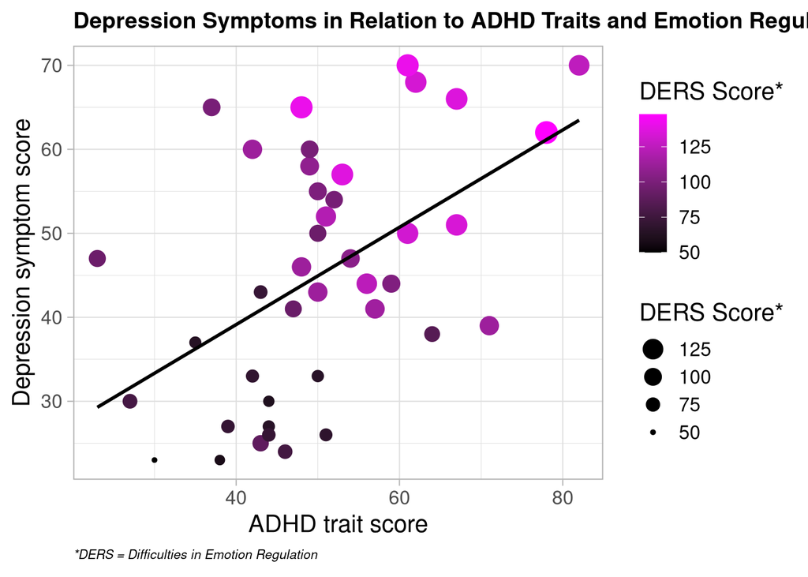

```r
p <- ggplot(df, aes(asrs, cesd,))
  p <- p +  geom_point(mapping = aes(size = ders, color = ders)) +
       geom_smooth(method = "lm", se = F, colour = "black") +
        scale_x_continuous(name="ADHD trait score") +
          scale_y_continuous(name="Depression symptom score") +
            scale_color_gradient(low = "black", high = "magenta") +
              guides(size = guide_legend(reverse = TRUE)) +
                themeadj
 p + ggtitle("Depression Symptoms in Relation to ADHD Traits and Emotion Regulation", ) +
      labs(color = "DERS Score*",
            size = "DERS Score*",
              caption = expression(italic("*DERS = Difficulties in Emotion Regulation")))
```

```r
ggsave("figs/hi_res.png", height=8, width = 10, units = "in")
```

A decision was made to keep the graph simple and clear to not detract from the importance of the findings.

## Shiny

Further graphs where plotted to determine whether ADHD trait type (Innatentive/Hyperactive), or individual construct of emotion regulation explained the relationship. These graphs where plotted and combined into a shiny widget which has been included below. If issues occur rendering then the shiny can be viewed [here](https://catsheen.shinyapps.io/PSY6422/?_ga=2.120579596.580671623.1621871213-742831662.1621871213)

```r
knitr::include_app("https://catsheen.shinyapps.io/PSY6422/?_ga=2.123750926.580671623.1621871213-742831662.1621871213",
  height = "700")
```

[interactive chart not shown]

```r
ui <- fluidPage(


    titlePanel("ADHD traits, Depression Symptoms and Emotion Regulation Domains"),

    sidebarPanel(

        selectInput('x', 'Reported Depression Symptoms', c("Depression Score" = 'cesd')),
        selectInput('y', 'ADHD trait type', c('Innatentive' = 'iasrs', 'Hyperactive' = "hasrs")),
        selectInput('ders', 'Emotion Regulation Difficulties per Domain', c("Non-Acceptance" = "nonaccept", 'Goals' = "goals", 'Impulse' = "impulse", 'Awareness' = "awareness", 'Strategies' = "strategies", 'Clarity' = "clarity")),
        #selectInput('size', 'Size', c(list("Non-Acceptance" = "nonaccept", Goals = "goals", Impulse = "impulse", Awareness = "awareness", Strategies = "strategies", Clarity = "clarity"))) #this line was unnecessary

    ),

    mainPanel(
        plotOutput('plot')
    )
)
```

```r
 server <-function(input, output) {
          output$plot <- renderPlot({

        p <- ggplot(df, aes_string(x=input$x, y=input$y)) + geom_point()

        (input$color)
            p <- p + aes_string(color=input$ders)

        (input$size)
            p <- p + aes_string(size=input$ders) + guides(size = guide_legend(reverse = TRUE))


    } )  }


 shinyApp(ui = ui, server = server)
```

Shiny applications not supported in static R Markdown documents